**Deep Learning for Mechanical Engineering**  
**Generative Adversarial Networks (GAN)**

Instructor: Prof. Seungchul Lee  
http://iai.postech.ac.kr/  
Industrial AI Lab at POSTECH

# Problem 1

(1) The Turing test, developed by Alan Turing in 1950, is a test of a machine's ability to exhibit intelligent behaviour equivalent to, or indistinguishable from, that of a human. Turing proposed that a human evaluator would judge natural language conversations between a human and a machine designed to generate human-like responses. The evaluator would be aware that one of the two partners in conversation is a machine, and all participants would be separated from one another. The conversation would be limited to a text-only channel such as a computer keyboard and screen so the result would not depend on the machine's ability to render words as speech. If the evaluator cannot reliably tell the machine from the human, the machine is said to have passed the test. The test results do not depend on the machine's ability to give correct answers to questions, only how closely its answers resemble those a human would give.

(Answer)  
Generators use latent code to create fake images similar to real images. And the discriminator distinguishes between real and fake images. The generator tries to trick the discriminator into judging a fake image as a real image, and the discriminator tries to find a fake image without being fooled by the generator. A model in which generators and discriminators learn against each other is called GAN.

(1-2) Write loss functions and optimizaton procedure.

(Answer)  
GAN loss can be defined as below

$${\min_G} \; {\max_D} \; V(D, G) = \mathbb{E}_{x\sim p_{data}{(x)}}[\log D(x)] + \mathbb{E}_{z\sim p_{z}{(z)}}[\log (1-D(G(z)))]$$

If the data that D is trying to determine is a sample from real data, D(x) becomes 1, the first term of the loss function disappears, and the fake image generated by G(z) can be distinguished. Therefore, D(G(z)) becomes 0. That is, the maximum value of the loss function that can be obtained from D's point of view is 0, and it is learned to maximize the loss function. From G's point of view, when D can be deceived, D(G(z)) becomes a value close to 1, and the generator is learned to minimize the loss function. Overall, optimization proceeds while the discriminator and generator try to maximize and minimize the loss function, respectively.

(2) You are training a GAN to generate nice human face images. The generator cost $J^{(G)}$ is extremly low, but the generator is not generating meaningful output images. What could be the reason? Describe it in relation to the loss function of the GAN.

(Answer)  
In the loss of the generator, $y = \log (1-x)$ form has a very small gradient value at $x = 0$. Therefore, learning does not work well at the beginning of the learning stage, and it is difficult to create a real image. To solve this problem, GAN loss is generally used by multiplying the loss function by ' - '.

# Problem 2

By the GAN algorithm, we can even change the style of images. In this problem, we will change the white-colored digit in a black background image to the black-colored digit in a white background image.

Download data from [here](https://www.dropbox.com/s/i6i2d12tzb7p2h1/one.npy?dl=1)

**Description**

- Domain A: white-colored number in a black background
- Domain B: black-colored number in a white background
- Generate Xab image by generator Gab
  - the structure of Gab is like an autoencoder
- Generate Xaba image by generator Gba
  - the structure of Gba is like an autoencoder
- Train the style to Gab generate styled image Xab
  - give reconstructed Xab image as a fake image and style image as a real image to the discriminator.

Note: I strongly recommend you to use either GPU or Colab. Don't use CPU to train your model! It will take a long time to complete training.

```python
import numpy as np
import matplotlib.pyplot as plt
import tensorflow as tf
```

(1) Load data. Then make colors of images inverted and plot one of them.

- one.npy
  - white-colored number in a black background image

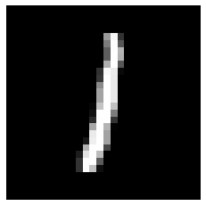

```python
Data_BB = np.load('./data_files/one.npy')

plt.imshow(Data_BB[0].reshape(28, 28), cmap = 'gray')
plt.axis('off')
plt.show()
```

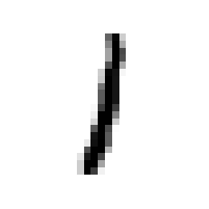

```python
Data_WB = 1 - Data_BB

plt.imshow(Data_WB[0].reshape(28, 28), cmap = 'gray')
plt.axis('off')
plt.show()
```

(2) Define your model.

- Generator AB
  - `n_G_input`: 28 $\times$ 28
  - `n_G_encoder1`: 256
  - `n_G_latent1`: 50
  - `n_G_decoder1`: 256
- Generator BA
  - `n_G_encoder2`: 256
  - `n_G_latent2`: 50
  - `n_G_decoder2`: 256
- Discriminator
  - `n_D_input`: 28 $\times$ 28
  - `n_D_hidden`: 256
  - `n_D_output`: 2

```python
Gab = tf.keras.models.Sequential([
    tf.keras.layers.Dense(256, activation = 'relu', input_shape = (28*28,)),
    tf.keras.layers.Dense(50, activation = 'relu'),
    tf.keras.layers.Dense(256, activation = 'relu'),
    tf.keras.layers.Dense(28*28, activation = 'sigmoid')
])

Gba = tf.keras.models.Sequential([
    tf.keras.layers.Dense(256, activation = 'relu', input_shape = (28*28,)),
    tf.keras.layers.Dense(50, activation = 'relu'),
    tf.keras.layers.Dense(256, activation = 'relu'),
    tf.keras.layers.Dense(28*28, activation = 'sigmoid')
])

Dis = tf.keras.models.Sequential([
    tf.keras.layers.Dense(256, activation = 'relu', input_shape = (28*28,)),
    tf.keras.layers.Dense(2, activation = 'sigmoid')
])

Dis.compile(optimizer = tf.keras.optimizers.Adam(learning_rate = 0.0001),
            loss = 'binary_crossentropy')
```

(3) Refer to the loss function below and train the model. And plot Xab image and Xaba image for each print.

Note that we are not asking you to make a perfect inverted image.

1: Fix $G$ and perform a gradient step to

$$\min_{D} E_{x \sim p_{\text{data}}(x)}\left[-\log D(x)\right] + E_{x \sim p_{z}(z)}\left[-\log (1-D(G(z)))\right]$$

2: Fix $D$ and perform a gradient step to

$$\min_{G} E_{x \sim p_{z}(z)}\left[-\log D(G(z))\right]$$

3: Minimize reconstruct error

$$\min \, (X_a-X_{aba})^2$$

```python
combined_input = tf.keras.layers.Input(shape = (28*28, ))
generated = Gab(combined_input)
Dis.trainable = False
combined_output = Dis(generated)

combined = tf.keras.models.Model(inputs = combined_input, outputs = combined_output)
combined.compile(optimizer = tf.keras.optimizers.Adam(learning_rate = 0.0001),
                 loss = 'binary_crossentropy')
```

```python
combined_recon_input = tf.keras.layers.Input(shape = (28*28,))
generated_recon = Gab(combined_recon_input)
combined_recon_output = Gba(generated_recon)

combined_recon = tf.keras.models.Model(inputs = combined_recon_input, outputs = combined_recon_output)
combined_recon.compile(optimizer = tf.keras.optimizers.Adam(learning_rate = 0.0001),
                       loss = 'mse')
```

```python
def plot_generated_images(one_img, Gab, Gba):

    idx = np.random.randint(0, one_img.shape[0], 1 )

    Gab_img = Gab.predict(one_img[idx].reshape(-1,28*28))
    Gab_img = Gab_img.reshape(28, 28)

    Gba_img = Gba.predict(Gab_img.reshape(-1,28*28)).reshape(28, 28)

    plt.figure(figsize = (9, 9))
    plt.subplot(1, 2, 1)
    plt.imshow(Gab_img, 'gray', interpolation = 'nearest')
    plt.title('Xab domain : black number in white background')
    plt.axis('off')
    plt.tight_layout()

    plt.subplot(1, 2, 2)
    plt.imshow(Gba_img, 'gray', interpolation = 'nearest')
    plt.title('Xba domain : white number in black background')
    plt.axis('off')
    plt.tight_layout()
    plt.show()
```

```
Epoch :  0
D_loss: 1.653404
G_loss: 0.631428
```

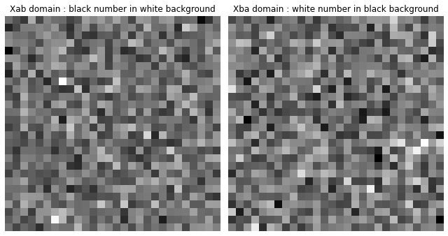

```
Epoch :  5000
D_loss: 1.324714
G_loss: 0.699074
```

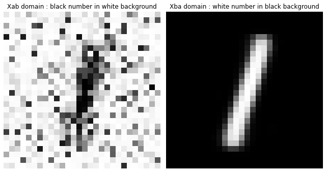

```
Epoch :  10000
D_loss: 1.249244
G_loss: 0.802790
```

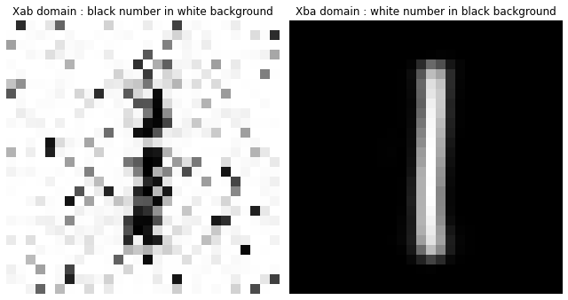

```
Epoch :  15000
D_loss: 0.962703
G_loss: 0.969717
```

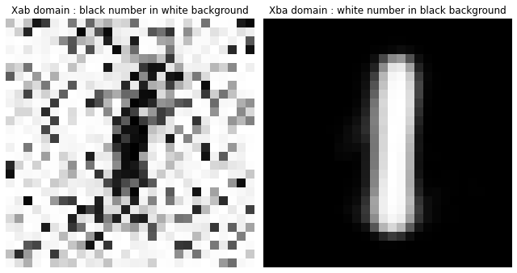

```
Epoch :  20000
D_loss: 1.127751
G_loss: 0.894138
```

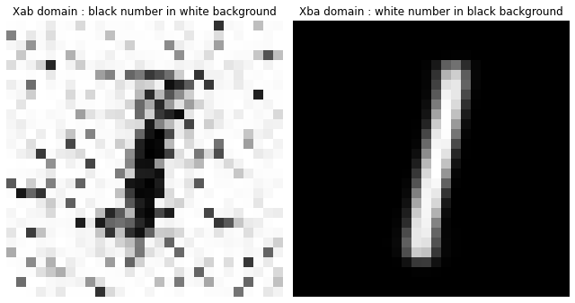

```
Epoch :  25000
D_loss: 1.322737
G_loss: 0.825942
```

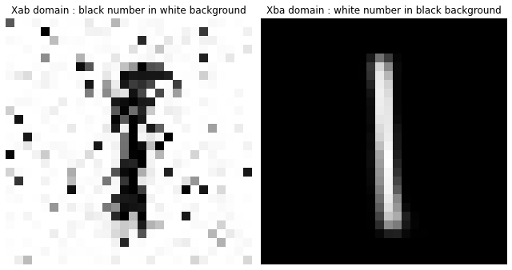

```python
batch_size = 1024
ones = np.ones(batch_size).reshape(-1, 1)
zeros = np.zeros(batch_size).reshape(-1, 1)

real = np.hstack([ones, zeros])
fake = np.hstack([zeros, ones])


for i in range(25001):
    idx = np.random.randint(0, Data_BB.shape[0], batch_size)

    Xab_img = Gab.predict(Data_BB[idx]) #Fake
    real_opposite = Data_WB[idx] #Real

    # Train Discriminator

    D_loss_real = Dis.train_on_batch(real_opposite, real)
    D_loss_fake = Dis.train_on_batch(Xab_img, fake)
    D_loss = D_loss_real + D_loss_fake

    # Train Generator

    G_loss = combined.train_on_batch(Data_BB[idx], real)

    # Train Reconstructor

    Re_loss = combined_recon.train_on_batch(Data_BB[idx], Data_BB[idx])

    if i % 5000 == 0:
        print('Epoch : ', i)
        print('D_loss: {:.6f}'.format(D_loss))
        print('G_loss: {:.6f}'.format(G_loss))

        plot_generated_images(Data_BB, Gab, Gba)
```

# Problem 3: GAN for Data Imbalance Problem

Most industries seriously consider and control their yield rate of production. For this reason, a huge amount of cost is required to control the yield rate and many industries try to replace this yield inspection process to reduce cost. However, the acquisition data from the industry are mostly normal data and seldomly fault data. (generally about less than 5% of normal data)

In this case, even if the deep learning model is a biased model (i.e., it considers every data as normal class), the accuracy would be 95%. So, in this case, we can't believe the result from the deep learning model.

One way to solve this problem is the 'data generation' method. In this problem, we are going to solve the classification problem for imbalanced data by the GAN model.

Download data from [here](https://www.dropbox.com/s/nxwfny61cyvbxem/GAN_P3_datafiles.zip?dl=1).

- data format: npy
- the number of data: one-6000, seven-300

Note: strongly recommend you to use GPU rather than CPU. (you can use CoLab GPU for free)

(1) Load and preprocess data.

**Step 1**: load

- one.npy
- seven.npy

**Step 2**: convert the loaded data to a binary image

**Step 3**: split into train/test dataset

- `one` train index: 0~999
- `one` test index: 1000~6000
- `seven` train index: 0~4 (only five images)
- `seven` test index: 5~300

**Step 4**: labeling

- one-hot encoding

**Step 5**: batchmaker

- train and test batchmakers

```python
import numpy as np
import matplotlib.pyplot as plt
%matplotlib inline

import tensorflow as tf
from sklearn.model_selection import train_test_split
```

```python
one = np.load('./data_files/one.npy')
seven = np.load('./data_files/seven.npy')

one = one.reshape(-1, 28, 28, 1)
seven = seven.reshape(-1, 28, 28, 1)
```

```python
one = one > 0.5
seven = seven > 0.5
```

```python
one_train = one[:1000]
seven_train = seven[:5]
one_test = one[1000:]
seven_test = seven[5:]
```

```python
train_data = np.concatenate([one_train, seven_train])
train_data = train_data
train_data.shape
```

```
(1005, 28, 28, 1)
```

```python
train_label = []
for i in range(len(one_train)):
    train_label.append(np.eye(2)[0])
for i in range(len(seven_train)):
    train_label.append(np.eye(2)[1])
train_label = np.array(train_label)
```

```python
test_data = np.concatenate([one_test, seven_test])
test_data = test_data
test_data.shape
```

```
(5295, 28, 28, 1)
```

```python
test_label = []
for i in range(len(one_test)):
    test_label.append(np.eye(2)[0])
for i in range(len(seven_test)):
    test_label.append(np.eye(2)[1])
test_label = np.array(test_label)
```

(2) Conduct the binary classification by convolution neural network (CNN) model.

**Model Training**

- Optimizer: AdamOptimizer
- Learning rate: $0.001$
- Epoch: $20$

**Model Test**

- radom image test
- `one` image test
- `seven` image test
- you should calculate the test accuracy

```python
# Build and train a model

model = tf.keras.models.Sequential([
    tf.keras.layers.Conv2D(filters = 32,
                           kernel_size = (3,3),
                           activation = 'relu',
                           padding = 'SAME',
                           input_shape = (28, 28, 1)),

    tf.keras.layers.MaxPool2D((2,2)),

    tf.keras.layers.Conv2D(filters = 64,
                           kernel_size = (3,3),
                           activation = 'relu',
                           padding = 'SAME'),

    tf.keras.layers.Flatten(),

    tf.keras.layers.Dense(100, activation = 'relu'),

    tf.keras.layers.Dense(2, activation = 'softmax')
])

model.compile(optimizer = 'adam',
              loss = 'categorical_crossentropy',
              metrics = 'accuracy')

model.fit(train_data,
          train_label,
          batch_size = 50,
          epochs = 20)
```

```
<tensorflow.python.keras.callbacks.History at 0x2015a4acf28>
```

```python
# test_dataset

test_loss, test_acc = model.evaluate(test_data, test_label)
```

[output not shown]

```python
# One image test

one_label = []
for i in range(len(one_test)):
    one_label.append(np.eye(2)[0])
one_label = np.array(one_label)

one_loss, one_acc = model.evaluate(one_test.reshape(-1, 28, 28, 1), one_label)
```

[output not shown]

```python
# Seven image test

seven_label = []
for i in range(len(seven_test)):
    seven_label.append(np.eye(2)[1])
seven_label = np.array(seven_label)

seven_loss, seven_acc = model.evaluate(seven_test, seven_label)
```

[output not shown]

**Generator**: deconvolution layer (= `conv2d_transpose`)

- Input layer: 100
- First deconvolution layer
  - filter size: $7\times 7$
  - channel: $64$
  - stride: $(1,1)$
  - padding: 'VALID'
- Second deconvolution layer:
  - filter size: $4\times 4$
  - channel: $32$
  - stride: $(2,2)$
  - padding: 'SAME'
- Third deconvolution layer
  - filter size: $4\times 4$
  - channel: $1$
  - stride: $(2,2)$
  - pading: 'SAME'

**Discriminator**: convolution layer

- Input layer: $28\times 28 \times 1$
- First convolution layer
  - filter size: $3\times 3$
  - channel: $32$
  - padding: 'SAME'
- Second convolution layer
  - filter size: $3\times 3$
  - channel: $64$
  - padding: 'SAME'
- no pooling layer

**Training**

- D_LR: 0.00004
- G_LR: 0.00008
- Max iteration: 5500
- Optimizer: AdamOptimizer

**Generated Images**

- Convert generated image to binary image
- original `one` images:original `seven` images + generated fake `seven` images = 1:1

```python
# Generator

n_G_input = 100

generator = tf.keras.models.Sequential([
    tf.keras.layers.Reshape((1, 1, 100), input_shape = (100,)),

    tf.keras.layers.Conv2DTranspose(filters = 64,
                                    kernel_size = (7,7),
                                    padding = 'VALID',
                                    activation = 'relu'),

    tf.keras.layers.Conv2DTranspose(filters = 32,
                                    kernel_size = (4,4),
                                    strides = (2,2),
                                    padding = 'SAME',
                                    activation = 'relu'),

    tf.keras.layers.Conv2DTranspose(filters = 1,
                                    kernel_size = (4,4),
                                    strides = (2,2),
                                    padding = 'SAME',
                                    activation = 'sigmoid')
])

generator.summary()
```

```
Model: "sequential_4"
_________________________________________________________________
Layer (type)                 Output Shape              Param #
=================================================================
reshape (Reshape)            (None, 1, 1, 100)         0
_________________________________________________________________
conv2d_transpose (Conv2DTran (None, 7, 7, 64)          313664
_________________________________________________________________
conv2d_transpose_1 (Conv2DTr (None, 14, 14, 32)        32800
_________________________________________________________________
conv2d_transpose_2 (Conv2DTr (None, 28, 28, 1)         513
=================================================================
Total params: 346,977
Trainable params: 346,977
Non-trainable params: 0
_________________________________________________________________
```

```python
# Discriminator

discriminator = tf.keras.models.Sequential([
    tf.keras.layers.Conv2D(filters = 32,
                           kernel_size = (3,3),
                           activation = 'relu',
                           padding = 'SAME',
                           input_shape = (28, 28, 1)),

    tf.keras.layers.Conv2D(filters = 64,
                           kernel_size = (3,3),
                           activation = 'relu',
                           padding = 'SAME'),

    tf.keras.layers.Flatten(),

    tf.keras.layers.Dense(100, activation = 'relu'),

    tf.keras.layers.Dense(1, activation = 'sigmoid')
])

discriminator.compile(optimizer = tf.keras.optimizers.Adam(learning_rate = 0.00004),
                      loss = 'binary_crossentropy')

discriminator.summary()
```

```
Model: "sequential_5"
_________________________________________________________________
Layer (type)                 Output Shape              Param #
=================================================================
conv2d_2 (Conv2D)            (None, 28, 28, 32)        320
_________________________________________________________________
conv2d_3 (Conv2D)            (None, 28, 28, 64)        18496
_________________________________________________________________
flatten_1 (Flatten)          (None, 50176)             0
_________________________________________________________________
dense_12 (Dense)             (None, 100)               5017700
_________________________________________________________________
dense_13 (Dense)             (None, 1)                 101
=================================================================
Total params: 5,036,617
Trainable params: 5,036,617
Non-trainable params: 0
_________________________________________________________________
```

```python
# Combined model

combined_input = tf.keras.layers.Input(shape = (100,))
generated = generator(combined_input)
discriminator.trainable = False
combined_output = discriminator(generated)

combined = tf.keras.models.Model(inputs = combined_input, outputs = combined_output)

combined.compile(optimizer = tf.keras.optimizers.Adam(learning_rate = 0.00008),
                 loss = 'binary_crossentropy')

combined.summary()
```

```
Model: "model_2"
_________________________________________________________________
Layer (type)                 Output Shape              Param #
=================================================================
input_3 (InputLayer)         [(None, 100)]             0
_________________________________________________________________
sequential_4 (Sequential)    (None, 28, 28, 1)         346977
_________________________________________________________________
sequential_5 (Sequential)    (None, 1)                 5036617
=================================================================
Total params: 5,383,594
Trainable params: 346,977
Non-trainable params: 5,036,617
_________________________________________________________________
```

```python
def make_noise(n_batch, n_G_input = n_G_input):
    return np.random.normal(size = (n_batch, n_G_input))

def seven_batchmaker(n_batch):
    idx = np.random.randint(len(seven_train), size = n_batch)
    return seven_train[idx]

def plot_generated_images(generator, samples = 3):
    noise = make_noise(samples)
    generated_images = generator.predict(noise)
    generated_images = generated_images.reshape(samples, 28, 28)
    for i in range(samples):
        plt.subplot(1, samples, i+1)
        plt.imshow(generated_images[i], 'gray', interpolation = 'nearest')
        plt.axis('off')
        plt.tight_layout()
    plt.show()
```

Step 1: Fix $G$ and perform a gradient step to

$$\min_{D} E_{x \sim p_{\text{data}}(x)}\left[-\log D(x)\right] + E_{x \sim p_{z}(z)}\left[-\log (1-D(G(z)))\right]$$

Step 2: Fix $D$ and perform a gradient step to

$$\min_{G} E_{x \sim p_{z}(z)}\left[-\log D(G(z))\right]$$

```
Iteration:  0
Discriminator Loss:  1.457717478275299
Generator Loss:  0.7238048315048218
```

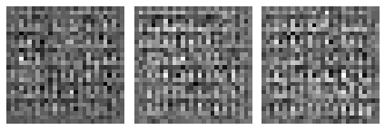

```
Iteration:  500
Discriminator Loss:  0.0002271014018333517
Generator Loss:  8.810637474060059
```

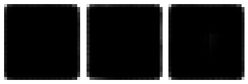

```
Iteration:  1000
Discriminator Loss:  0.0003195768513251096
Generator Loss:  12.902491569519043
```

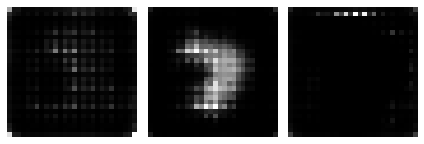

```
Iteration:  1500
Discriminator Loss:  0.0001393060592818074
Generator Loss:  13.090432167053223
```

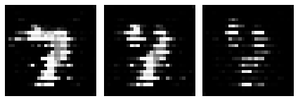

```
Iteration:  2000
Discriminator Loss:  0.0003331830812385306
Generator Loss:  10.377161979675293
```

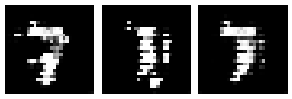

```
Iteration:  2500
Discriminator Loss:  0.0008263410854851827
Generator Loss:  10.292074203491211
```

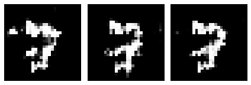

```
Iteration:  3000
Discriminator Loss:  0.021185402758419514
Generator Loss:  7.768906116485596
```

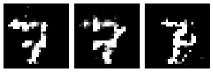

```
Iteration:  3500
Discriminator Loss:  0.0074745777528733015
Generator Loss:  7.491140842437744
```

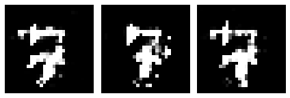

```
Iteration:  4000
Discriminator Loss:  0.010550980921834707
Generator Loss:  7.811800479888916
```

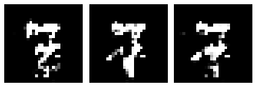

```
Iteration:  4500
Discriminator Loss:  0.003688627853989601
Generator Loss:  7.656737804412842
```

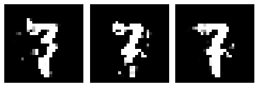

```
Iteration:  5000
Discriminator Loss:  0.011273189913481474
Generator Loss:  8.94155502319336
```

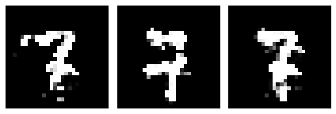

```python
n_iter = 5500
n_prt = 500
batch_size = 100

fake = np.zeros(batch_size)
real = np.ones(batch_size)

for i in range(n_iter):
    train_x = seven_batchmaker(batch_size)

    # Train Discriminator

    noise = make_noise(batch_size)
    generated_images = generator.predict(noise)

    idx = np.random.randint(0, train_x.shape[0], batch_size)
    real_images = train_x[idx]

    D_loss_real = discriminator.train_on_batch(real_images, real)
    D_loss_fake = discriminator.train_on_batch(generated_images, fake)
    D_loss = D_loss_real + D_loss_fake

    # Train Generator

    noise = make_noise(batch_size)
    G_loss = combined.train_on_batch(noise, real)

    if i % n_prt == 0:
        print('Iteration: ', i)
        print('Discriminator Loss: ', D_loss)
        print('Generator Loss: ', G_loss)

        plot_generated_images(generator)
```

```python
# save generated data
# N = len(one) - len(seven)

N = len(one_train) - len(seven_train)
noise = make_noise(N, n_G_input)
generated_img = generator.predict(noise)
generated_img = generated_img > 0.5
```

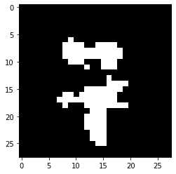

```python
# Randomly plot one generated image among N

idx = np.random.randint(len(generated_img))
plt.imshow(generated_img[idx].reshape(28, 28), 'gray')
```

(4) Train the CNN model again using the original and generated (or augmented) data.

- stack the generated data and original train data of `seven`
- define new train data by putting new `seven` train and `one` train data altogether
- define new train label
- use the same CNN structure
- test
  - random image test
  - one image test
  - seven image test

```python
new_seven_train = np.vstack([generated_img, seven_train])
new_train_data = np.concatenate([one_train, new_seven_train])

new_train_label = []
for i in range(len(one_train)):
    new_train_label.append(np.eye(2)[0])
for i in range(len(new_seven_train)):
    new_train_label.append(np.eye(2)[1])
new_train_label = np.array(new_train_label)

print('new_train_data: ', new_train_data.shape)
```

```
new_train_data:  (2000, 28, 28, 1)
```

```python
model = tf.keras.models.Sequential([
    tf.keras.layers.Conv2D(filters = 32,
                           kernel_size = (3,3),
                           activation = 'relu',
                           padding = 'SAME',
                           input_shape = (28, 28, 1)),

    tf.keras.layers.MaxPool2D((2,2)),

    tf.keras.layers.Conv2D(filters = 64,
                           kernel_size = (3,3),
                           activation = 'relu',
                           padding = 'SAME'),

    tf.keras.layers.Flatten(),

    tf.keras.layers.Dense(100, activation = 'relu'),

    tf.keras.layers.Dense(2, activation = 'softmax')
])

model.compile(optimizer = 'adam',
              loss = 'categorical_crossentropy',
              metrics = 'accuracy')

model.fit(new_train_data,
          new_train_label,
          batch_size = 50,
          epochs = 20)
```

```
<tensorflow.python.keras.callbacks.History at 0x20150fabb38>
```

```python
# test_dataset

test_loss, test_acc = model.evaluate(test_data, test_label)
```

[output not shown]

```python
# one image test

one_loss, one_acc = model.evaluate(one_test, one_label)
```

[output not shown]

```python
# seven image test

seven_loss, seven_acc = model.evaluate(seven_test, seven_label)
```

[output not shown]